# Anàlisi de la cohort de CRC utilitzant informació de MCN

## Preparació de les dades per a l’anàlisi

El fitxer de dades amb informació de l’estat WGD (Bielski) conté 207 casos de la cohort de COADREAD.

Tenim 698 fitxers de recomptes de la cohort de CRC.

L’anàlisi inclourà 206 mostres, 137 mostres sense WGD i 69 mostres amb WGD. Un 33% de les mostres de l’anàlisi han patit WGD.

La mida de les llibreries varia entre 5.41226810^{6} i 1.405262910^{8} i la mida mitjana és de 6.41743210^{7}.

## Pre-processament de les dades

Per a la filtració s’ha utilitzat un llindar de CPM de 0.15 i s’han filtrat 39759 gens, és a dir un 66% dels gens que teníem inicialment.

El rang de valors dels factors de normalització és de 0.5940644, 1.3152772.

## Exploració de les dades

### Gràfics de densitat

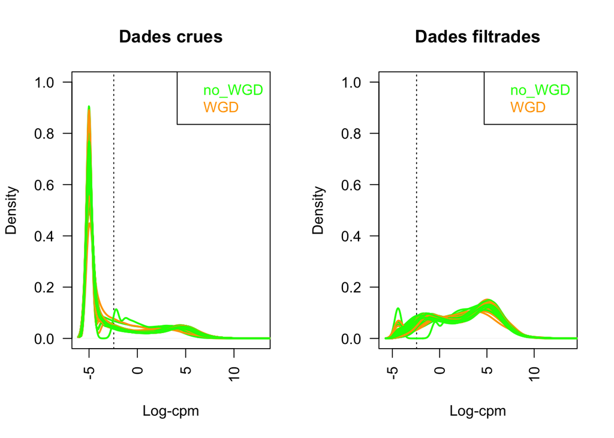

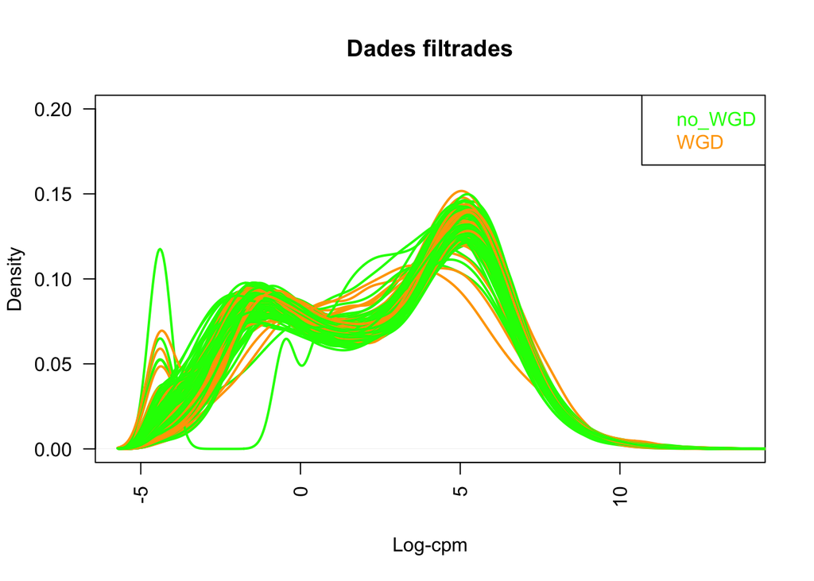

### Gràfic d’escalat multidimensional

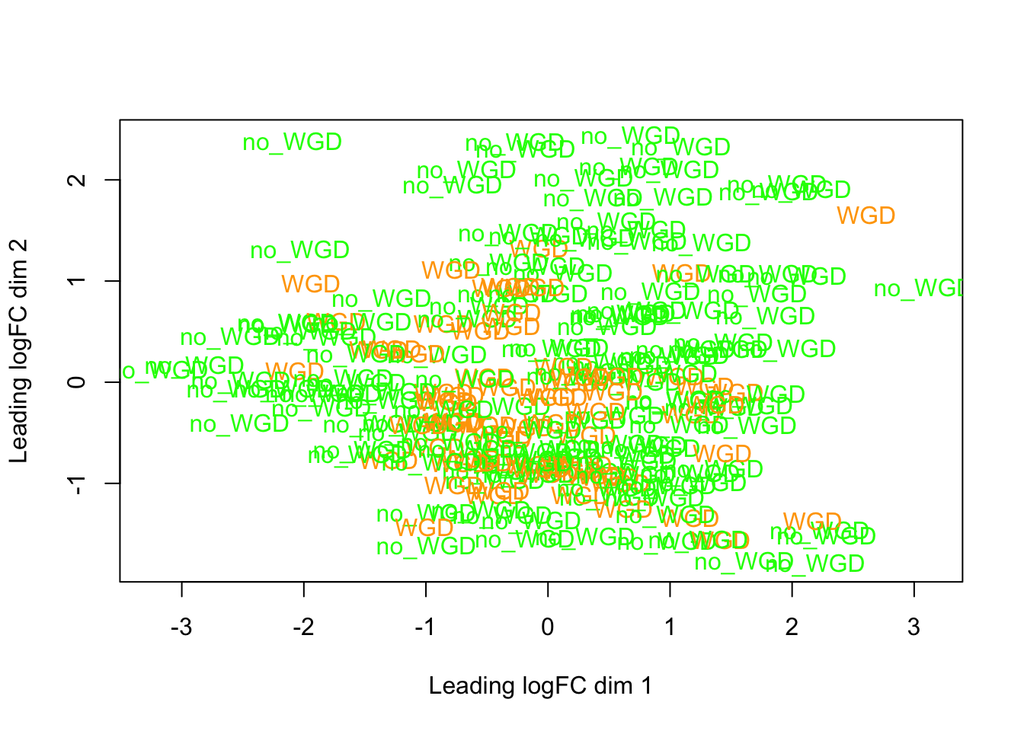

### Heatmap del gens més variables

Matriu de distàncies dels logCPM dels gens més variables. En aquest cas extraiem els 500 gens més variables a partir de les dades filtrades i normalitzades.

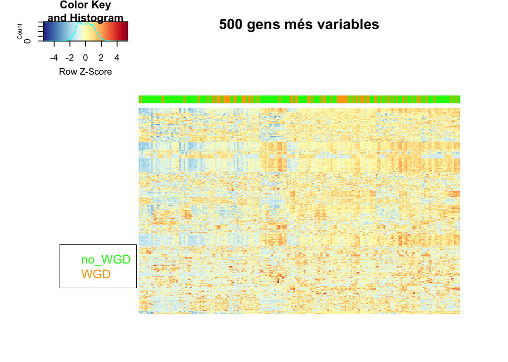

## Resultats de l’anàlisi d’expressió diferencial

### Nombre de gens diferencialment expressats

Contrastos amb p-valor ajustat (FDR) inferior a 0.05:

```
##        WGDvsNoWGD
## Down          468
## NotSig      19532
## Up            724
```

Contrastos amb p-valor sense ajustar inferior a 0.05 i valor absolut de log2-fold-change superior a 0.5 , aproximadament equivalent a un fold-change de 0.7 i 1.4:

```
##        WGDvsNoWGD
## Down          155
## NotSig      19810
## Up            759
```

### Llista de gens ordenats per significació

```
##       ensembl_gene_id hgnc_symbol      logFC      P.Value    adj.P.Val
## 2302  ENSG00000101216       GMEB2  0.3681085 8.322500e-08 0.0002874592
## 2451  ENSG00000102287       GABRE  1.0004802 5.670583e-08 0.0002874592
## 7011  ENSG00000139160     ETFBKMT -0.5017012 7.346938e-08 0.0002874592
## 11695 ENSG00000173011      TADA2B -0.2898372 7.406609e-08 0.0002874592
## 15674 ENSG00000216588      IGSF23  1.3851878 5.848588e-08 0.0002874592
## 16637 ENSG00000231683              1.8463130 8.270007e-08 0.0002874592
## 20073 ENSG00000274080              1.0339414 1.057801e-07 0.0003131695
## 6014  ENSG00000132801      ZSWIM3  0.5682054 2.607236e-07 0.0006754046
## 1249  ENSG00000076043       REXO2 -0.3975341 3.071872e-07 0.0006853610
## 9222  ENSG00000159596      TMEM69 -0.3375368 3.307088e-07 0.0006853610
## 19812 ENSG00000272328              1.2265909 3.735336e-07 0.0007037373
## 814   ENSG00000063978        RNF4 -0.2446823 5.480788e-07 0.0007408836
## 2295  ENSG00000101193        GID8  0.3216723 6.252177e-07 0.0007408836
## 6223  ENSG00000134440       NARS1 -0.3612541 6.435006e-07 0.0007408836
## 10575 ENSG00000166913       YWHAB  0.3975756 4.475432e-07 0.0007408836
## 10968 ENSG00000168818       STX18 -0.2791444 6.364393e-07 0.0007408836
## 14506 ENSG00000198276       UCKL1  0.4300823 5.125924e-07 0.0007408836
## 15493 ENSG00000214050      FBXO16 -0.9978094 5.399447e-07 0.0007408836
## 7889  ENSG00000145949       MYLK4  0.6203944 6.799084e-07 0.0007416012
## 5010  ENSG00000124228       DDX27  0.4769216 8.201147e-07 0.0008151635
```

### Representació gràfica dels resultats

#### Gràfic mitjana-diferència

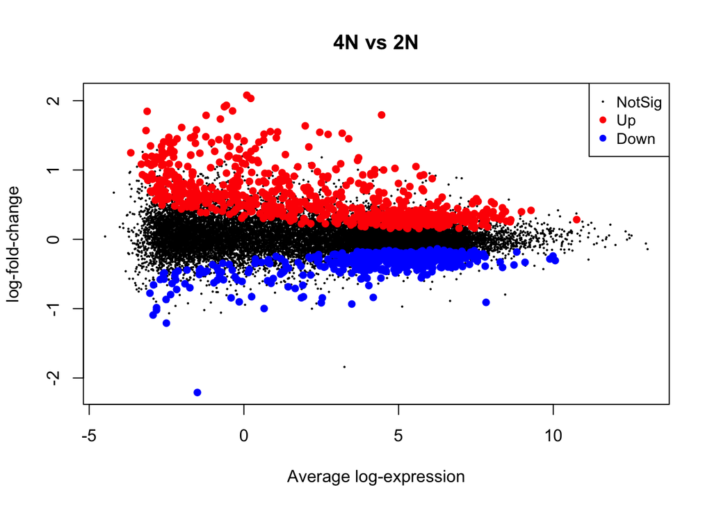

#### Gràfic de volcà

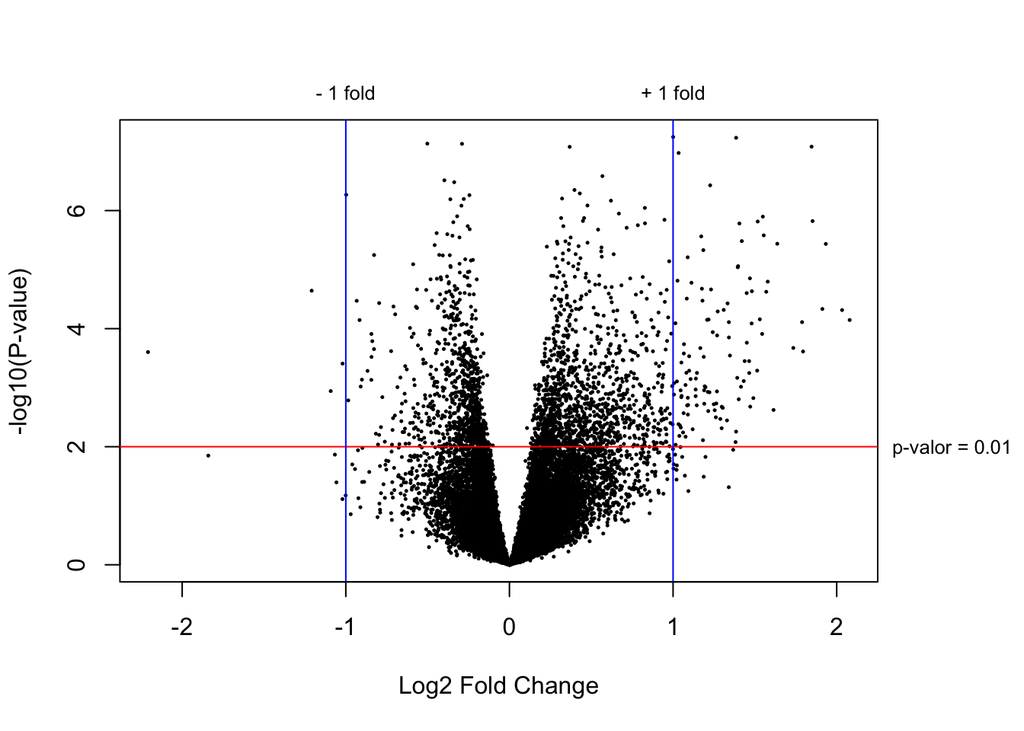

#### Heatmap dels gens més significatius

100 gens amb p-valor ajustat més baix:

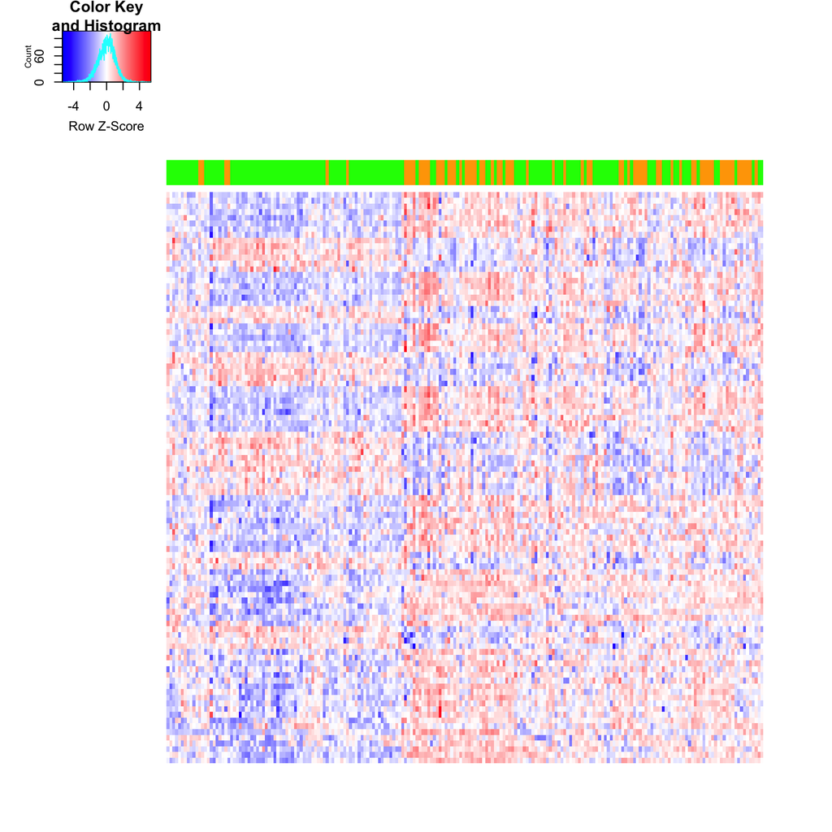

100 gens amb p-valor ajustat més baix després d’haver filtrat per aquells gens amb un logFC en valor absolut superior a 0.5 (aproximadament equivalent a FC superior a 1.4 o inferior a 0.7):

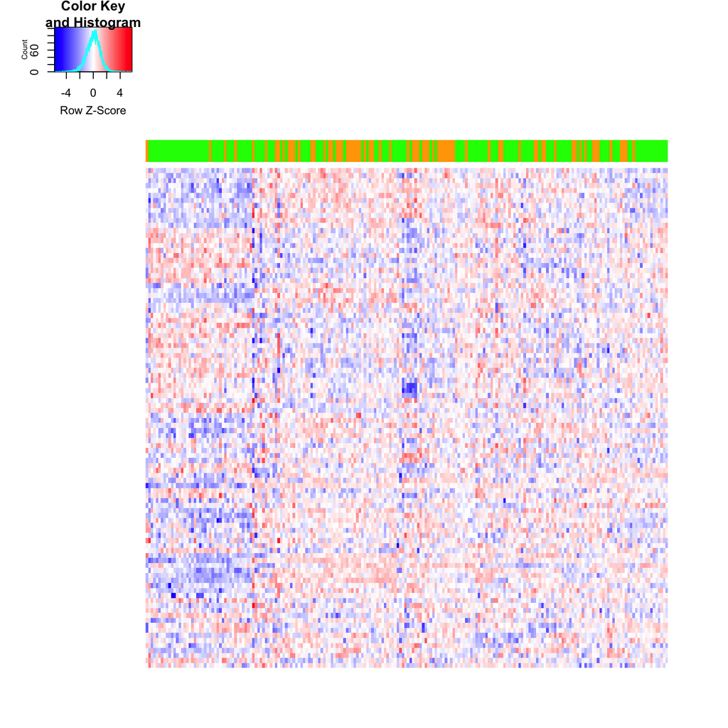

## Resultats de l’anàlisi d’enriquiment amb permutació de gene sets

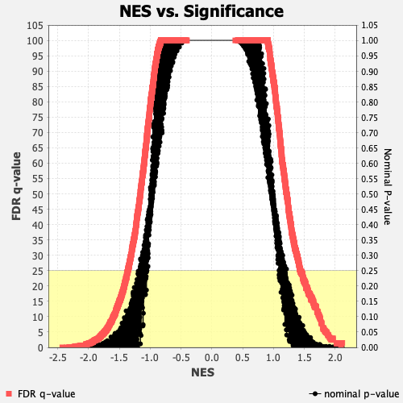

Termes enriquits al grup WGD

| NAME | FDR.q.val | NES |
| --- | --- | --- |
| GO_COLLAGEN_FIBRIL_ORGANIZATION | 0.0143526 | 2.114425 |
| GO_POSTSYNAPSE_ASSEMBLY | 0.0090740 | 2.095758 |
| GO_REGULATION_OF_CHONDROCYTE_DIFFERENTIATION | 0.0143274 | 2.047866 |
| GO_REGULATION_OF_CARTILAGE_DEVELOPMENT | 0.0116929 | 2.041831 |
| GO_PRESYNAPSE_ORGANIZATION | 0.0123608 | 2.020375 |
| GO_AMINE_TRANSPORT | 0.0296649 | 1.964030 |
| GO_POSTSYNAPTIC_SPECIALIZATION_ASSEMBLY | 0.0262875 | 1.962543 |
| GO_EMBRYONIC_EYE_MORPHOGENESIS | 0.0244204 | 1.959568 |
| GO_CATECHOLAMINE_SECRETION | 0.0288330 | 1.942934 |
| GO_NEUROPEPTIDE_SIGNALING_PATHWAY | 0.0266293 | 1.941518 |
| GO_NEGATIVE_REGULATION_OF_CARTILAGE_DEVELOPMENT | 0.0249632 | 1.939834 |
| GO_SYNAPSE_ASSEMBLY | 0.0250194 | 1.934316 |
| GO_REGULATION_OF_SYNAPSE_ASSEMBLY | 0.0291318 | 1.919020 |
| GO_REGULATION_OF_POSTSYNAPTIC_DENSITY_ORGANIZATION | 0.0332455 | 1.907406 |
| GO_NEGATIVE_REGULATION_OF_CELLULAR_RESPONSE_TO_GROWTH_FACTOR_STIMULUS | 0.0400248 | 1.891753 |
| GO_NEURON_FATE_SPECIFICATION | 0.0380436 | 1.890987 |
| GO_POSTSYNAPTIC_SPECIALIZATION_ORGANIZATION | 0.0380709 | 1.887132 |
| GO_CHONDROCYTE_DIFFERENTIATION | 0.0415680 | 1.877896 |
| GO_HOMOPHILIC_CELL_ADHESION_VIA_PLASMA_MEMBRANE_ADHESION_MOLECULES | 0.0462431 | 1.867290 |
| GO_REGULATION_OF_ANIMAL_ORGAN_FORMATION | 0.0502593 | 1.857971 |

Termes enriquits al grup no_WGD

| NAME | FDR.q.val | NES |
| --- | --- | --- |
| GO_NATURAL_KILLER_CELL_MEDIATED_IMMUNITY | 0.0000000 | -2.423958 |
| GO_MYELOID_CELL_APOPTOTIC_PROCESS | 0.0000000 | -2.357510 |
| GO_RESPONSE_TO_INTERFERON_GAMMA | 0.0005265 | -2.314513 |
| GO_CD4_POSITIVE_ALPHA_BETA_T_CELL_CYTOKINE_PRODUCTION | 0.0007870 | -2.307716 |
| GO_DEFENSE_RESPONSE_TO_VIRUS | 0.0009580 | -2.293019 |
| GO_REGULATION_OF_NATURAL_KILLER_CELL_MEDIATED_IMMUNITY | 0.0007983 | -2.280605 |
| GO_INTERFERON_GAMMA_PRODUCTION | 0.0026690 | -2.229449 |
| GO_INTERFERON_GAMMA_MEDIATED_SIGNALING_PATHWAY | 0.0023354 | -2.222970 |
| GO_POSITIVE_REGULATION_OF_NATURAL_KILLER_CELL_MEDIATED_IMMUNITY | 0.0029359 | -2.213384 |
| GO_RESPONSE_TO_VIRUS | 0.0029620 | -2.208716 |
| GO_DIOL_METABOLIC_PROCESS | 0.0031205 | -2.198049 |
| GO_NATURAL_KILLER_CELL_ACTIVATION | 0.0040237 | -2.180905 |
| GO_CELLULAR_DEFENSE_RESPONSE | 0.0042030 | -2.175907 |
| GO_INTERLEUKIN_2_PRODUCTION | 0.0041237 | -2.166106 |
| GO_POSITIVE_REGULATION_OF_INTERLEUKIN_2_PRODUCTION | 0.0045901 | -2.150687 |
| GO_POSITIVE_REGULATION_OF_INTERFERON_GAMMA_PRODUCTION | 0.0051970 | -2.135355 |
| GO_SPHINGOID_METABOLIC_PROCESS | 0.0050809 | -2.132982 |
| GO_POSITIVE_REGULATION_OF_CYTOKINE_BIOSYNTHETIC_PROCESS | 0.0048840 | -2.131821 |
| GO_CELLULAR_RESPONSE_TO_INTERFERON_BETA | 0.0047934 | -2.129584 |
| GO_CELLULAR_RESPONSE_TO_VIRUS | 0.0046330 | -2.125945 |

## Anàlisis d’immunitat

### ESTIMATE

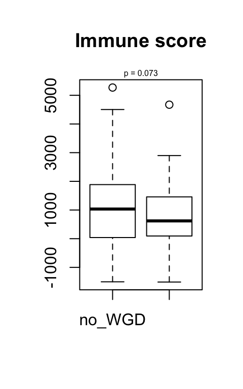

### Immunophenoscore

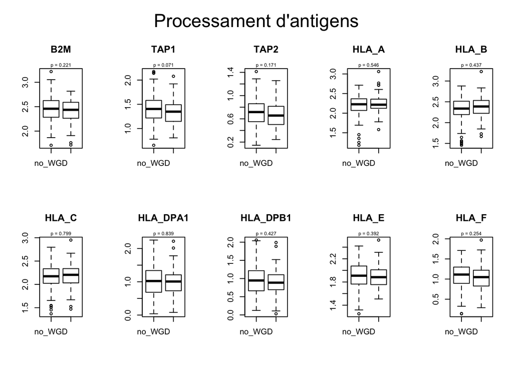

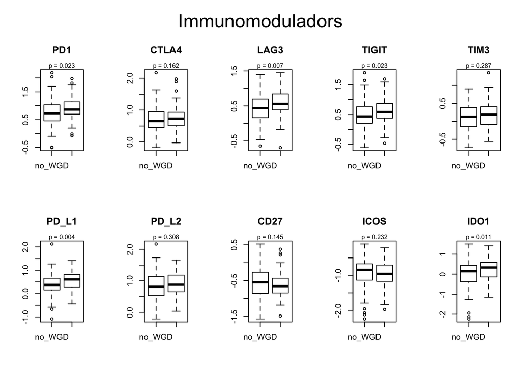

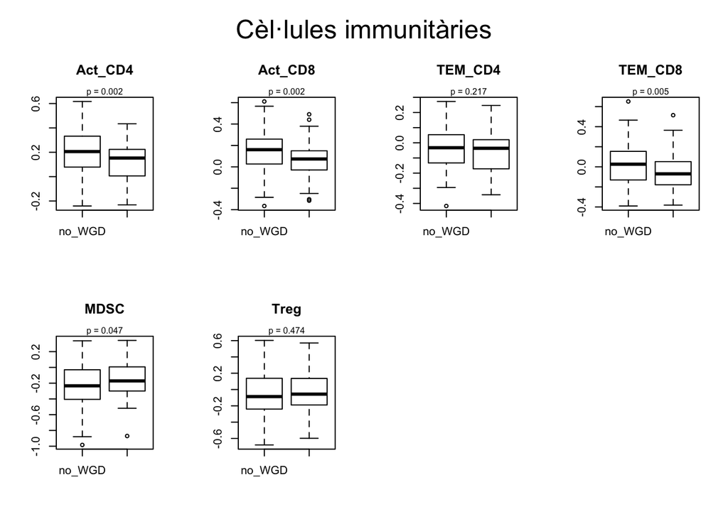

### Signatura 12-Chemokines

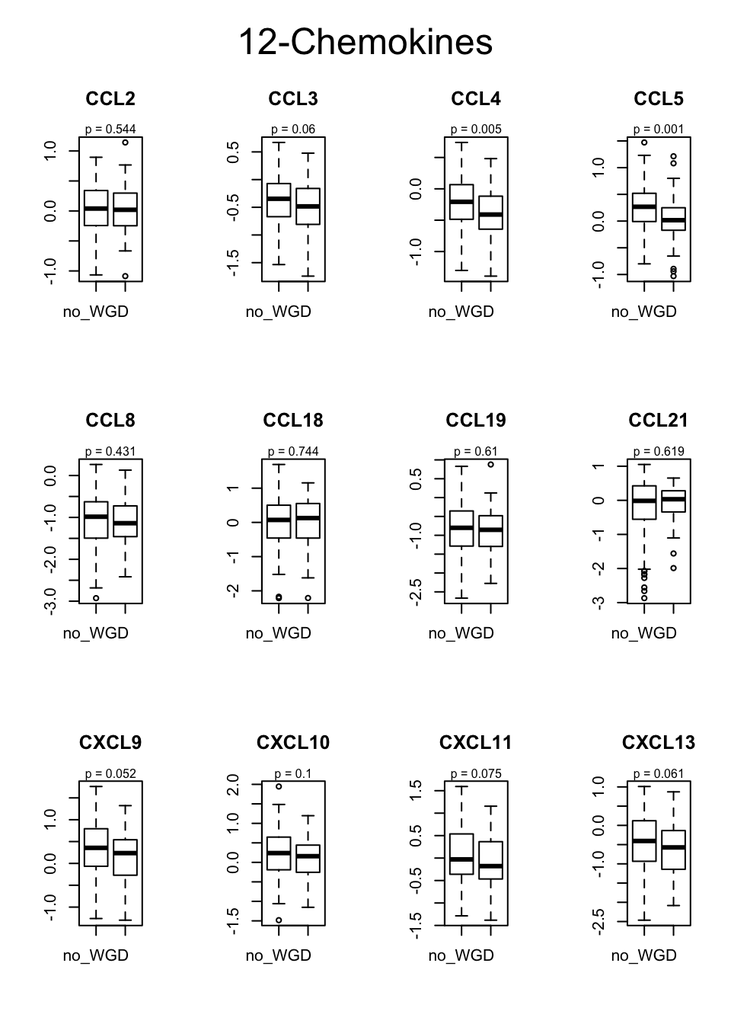